# Cartographie avec R - Exercices

# mapsf

2. Installez le package `mapsf`.

```r
install.packages("mapsf")
```

3. Quelle est la version du package?

```r
packageVersion("mapsf")
```

```
#> [1] '0.11.0'
```

4. Quelles sont les nouveautés par rapport à la version précédente?

Voir le [*changelog*](https://riatelab.github.io/mapsf/news/) sur le site du package.

# La sémiologie graphique

Comment représenter les variables suivantes :

- Une population communale **-> carte de symboles proportionnels, tailles**
- Un age médian par département **-> carte choroplèthe, valeurs**
- Un taux de croissance **-> carte choroplèthe, valeurs**
- Le statut administratif d’une commune (préfecture, sous-préfecture, commune simple…) **-> carte de typologie, couleurs ou formes différentes**
- L’espérance de vie par pays **-> carte choroplèthe, valeur**

# Les types de cartes

1. Importer la couche des communes du département du Lot à partir du fichier geopackage **lot.gpkg**.

```r
library(sf)
st_layers('data/lot.gpkg')
```

```
#> Driver: GPKG
#> Available layers:
#>     layer_name geometry_type features fields              crs_name
#> 1     communes Multi Polygon      313     12 RGF93 v1 / Lambert-93
#> 2 departements Multi Polygon       96      5 RGF93 v1 / Lambert-93
#> 3  restaurants         Point      694      2 RGF93 v1 / Lambert-93
#> 4   elevations         Point     5228      1 RGF93 v1 / Lambert-93
#> 5       routes   Line String     1054      2 RGF93 v1 / Lambert-93
```

```r
com_raw <- st_read("data/lot.gpkg", layer = "communes", quiet = TRUE)
```

2. Importer le fichier **com.csv**.  
   Ce jeu de données porte sur les communes du Lot et contient plusieurs variables supplémentaires:
   - le nombre d’actifs (**ACT**).
   - le nombre d’actifs dans l’industrie (**IND**)
   - la part des actifs dans la population totale (**SACT**)
   - la part des actifs dans l’industrie dans le total des actifs (**SACT_IND**)

```r
com_df <- read.csv("data/com.csv")
```

3. Joindre le jeu de données et la couche des communes.

```r
com <- merge(com_raw, com_df, by = "INSEE_COM", all.x = TRUE)
```

4. Créer une carte de la population active.

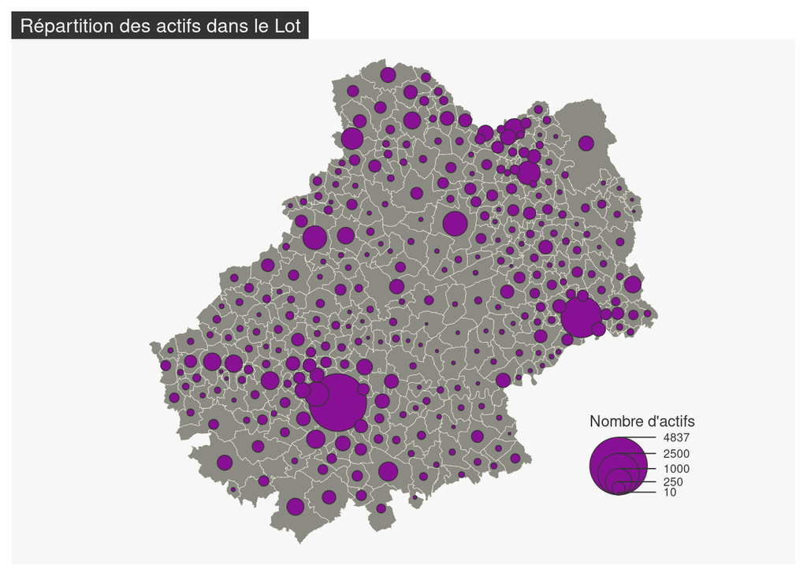

```r
library(mapsf)
# afficher les communes
mf_map(com, col = "ivory4", border = "ivory" , lwd = .3)
# afficher des cercles proportionnels
mf_map(x = com, var = "ACT", type = "prop",
       inches = .25, lwd = .75, col = "#881094",
       leg_title = "Nombre d'actifs",
       leg_pos = c(622700, 6372800))
mf_title("Répartition des actifs dans le Lot")
```

5. Créer une carte de la part de la population active dans la population totale.

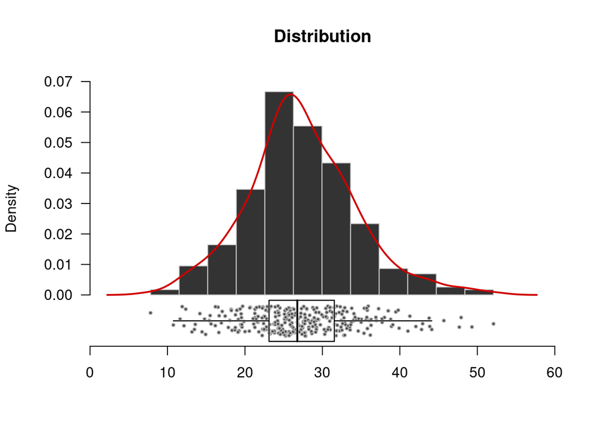

```r
# Étude de la distribution
mf_distr(com$SACT)
```

```r
summary(com$SACT)
```

```
#>    Min. 1st Qu.  Median    Mean 3rd Qu.    Max.
#>   7.812  23.104  26.754  27.265  31.537  52.083
```

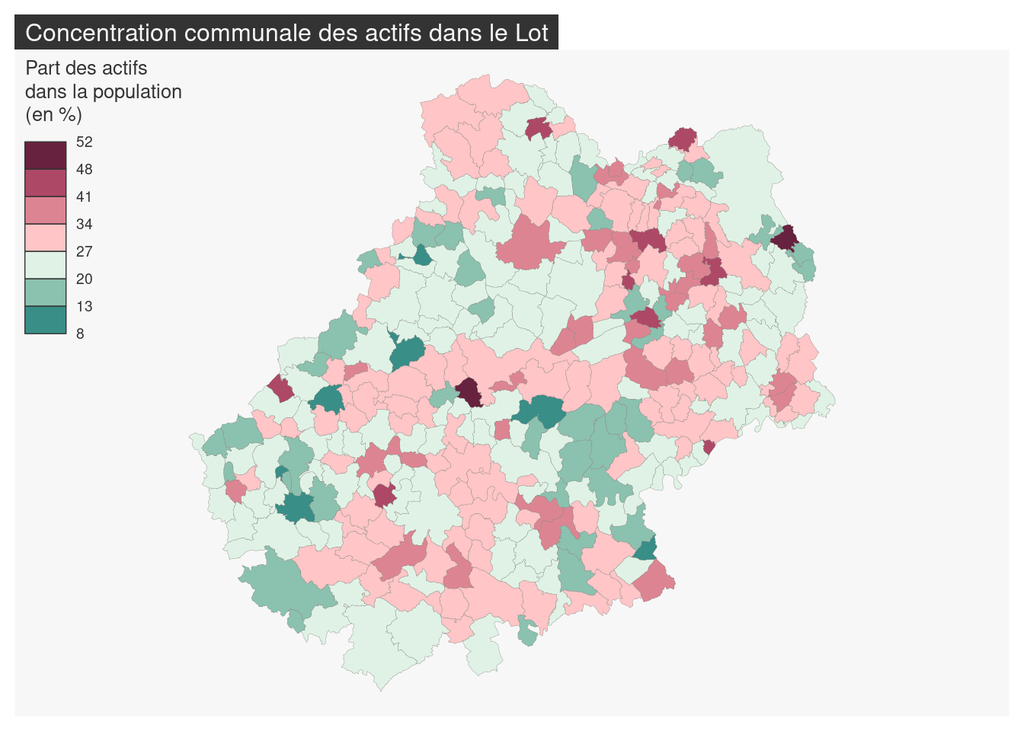

```r
# choix de la méthode msd (utilisant moyenne et écart-type)
bks <- mf_get_breaks(com$SACT, breaks = "msd", central = FALSE)
# Utilisation d'une palette dissymétrique équilibrée autour de la moyenne
cols <- mf_get_pal(c(3,4), palette = c("Mint", "Burg"))

# Création de la carte
mf_map(x = com, var = "SACT", type = "choro",
       breaks = bks, pal = cols,
       border = "ivory4", lwd = .2,
       leg_title = "Part des actifs\ndans la population\n(en %)",
       leg_val_rnd = 0)
mf_title("Concentration communale des actifs dans le Lot")
```

# La mise en page

1. Importer la couche des communes du département du Lot à partir du fichier geopackage **lot.gpkg**.
2. Importer le fichier **com.csv**.  
   Ce jeu de données porte sur les communes du lot et contient plusieurs variables supplémentaires:
   - le nombre d’actifs (**ACT**).
   - le nombre d’actifs dans l’industrie (**IND**)
   - La part des actifs dans la population totale (**SACT**)
   - La part des actifs dans l’industrie dans le total des actifs (**SACT_IND**)
3. Joindre le jeu de données et la couche des communes.
4. Créez une carte représentant la population active travaillant dans l’industrie.
5. Ajoutez les éléments d’habillage indispensables.
6. Utilisez un thème personnalisé.
7. Ajoutez un carton de localisation du Lot.
8. Exportez la carte au format PNG avec 800 pixels de large.
9. Comment rendre la carte plus intelligible ? Allez-y !

```r
library(sf)
library(mapsf)
# import des communes du Lot
com <- st_read("data/lot.gpkg", layer = "communes", quiet = TRUE)
# import du jeu de données
com_df <- read.csv("data/com.csv")
# jointure
com <- merge(com, com_df, by = "INSEE_COM", all.x = TRUE)
# import des départments français
dep <- st_read("data/lot.gpkg", layer = "departements", quiet = TRUE)

# Création et application d'un thème personnalisé
mf_theme("green", mar = c(0,0,1.5,0), pos = "left")
# couleur principale utilisée
mf_theme()$fg
```

```
#> [1] "#D7FF68"
```

```r
# Cartographie du nombre total de travailleurs de l'industrie
mf_export(com, "img/n_ind.png", width = 800)
mf_map(x = com, border = "white", lwd = .2, add = T)
mf_map(x = dep, lwd = 1, col = NA, add = TRUE, lend = 0)
mf_map(x = com, var = "IND", type = "prop",
       leg_title = "Nombre d'actifs\ntravaillant dans\nl'industrie")
```

```
#> 50 '0' values are not plotted on the map.
```

```r
mf_title("Répartition des actifs travaillant dans l'industrie - 2017")
mf_scale(5)
mf_arrow(pos = "topright")
# notez l'utilisation ici de paste0() qui permet de concatener des chaines
# de caractères et de \n qui permet d'aller à la ligne
mf_credits(paste0("Admin Express COG Carto 3.0, IGN - 2021 & ",
                  "BD CARTO® 4.0, IGN - 2021 ; Recensements harmonisés - ",
                  "Séries départementales et communales, INSEE - 2020\n",
                  "Auteurs : T. Giraud & H. Pecout, 2024"))
dev.off()
```

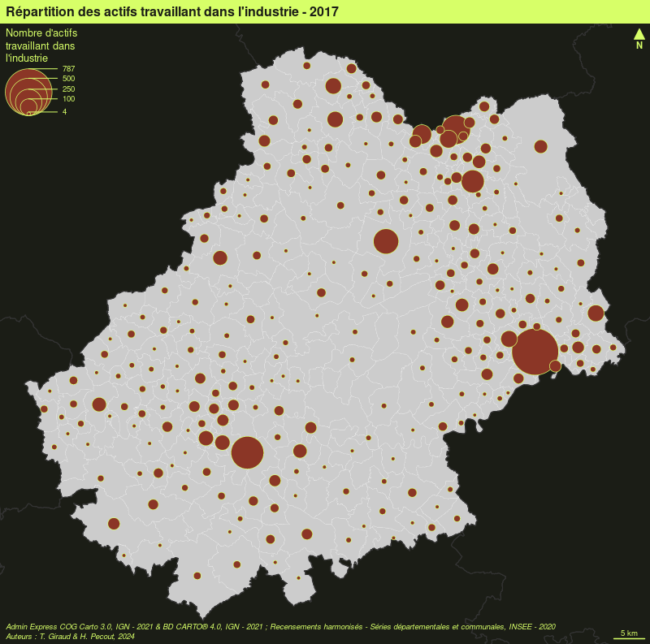

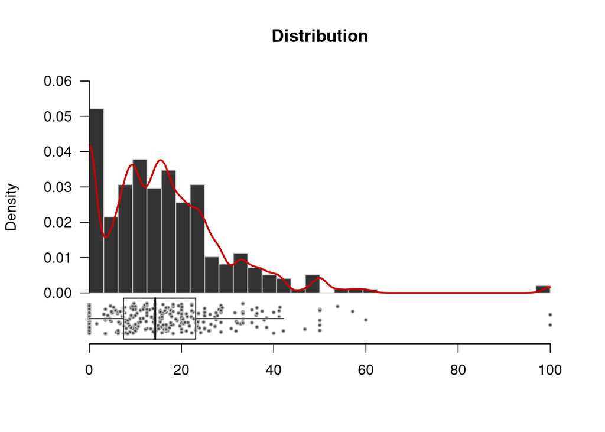

```r
# Cartographie de la part des actifs travaillant dans l'industrie
## Quelle est la forme de la distribution que nous voulons cartographier ?
mf_distr(com$SACT_IND)
```

```r
summary(com$SACT_IND)
```

```
#>    Min. 1st Qu.  Median    Mean 3rd Qu.    Max.
#>   0.000   7.407  14.286  16.282  23.077 100.000
```

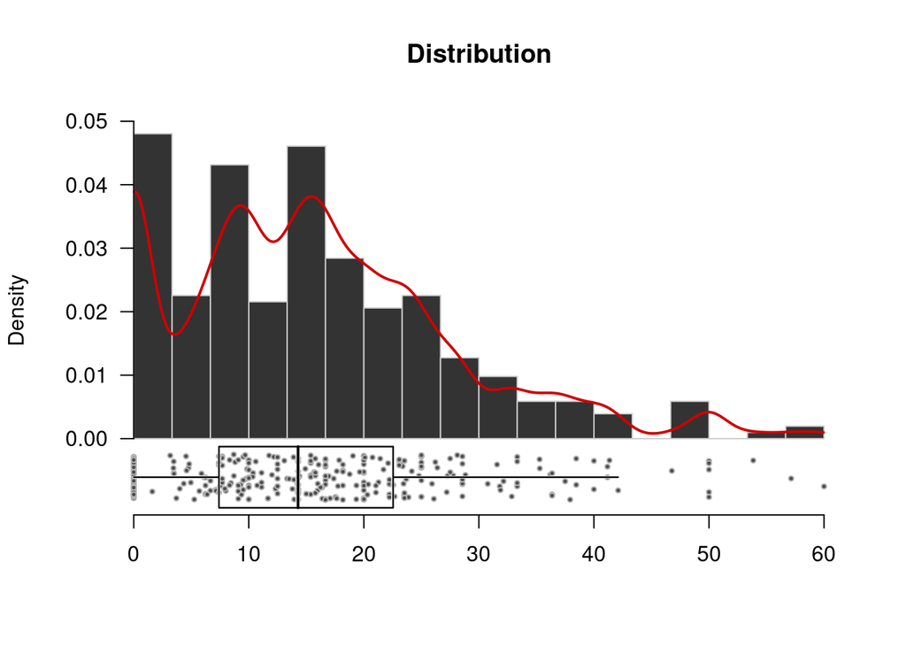

```r
#### > Seules 2 communes ont 100% de travailleurs dans l'industrie
#### Ces communes ont moins de 15 actifs
# Sélection des communes ayant plus de 15 actifs
com_sel <- com[com$ACT > 15, ]
## Quelle est la forme de cette (nouvelle) distribution
mf_distr(com_sel$SACT_IND)
```

```r
summary(com_sel$SACT_IND)
```

```
#>    Min. 1st Qu.  Median    Mean 3rd Qu.    Max.
#>   0.000   7.408  14.286  15.783  22.466  60.000
```

```r
# Creation d'un vecteur contenant les limites de classes en
# utilisant la méthode des quantiles
bks <- mf_get_breaks(com_sel$SACT_IND, nbreaks = 5, breaks = "quantile")
```

```r
# export de la carte
mf_export(com, "img/s_ind.png", width = 800)
# Cartographie
mf_map(x = com,
       var = "SACT_IND",
       type = "choro",
       breaks = bks,         # Utilisation des bornes de classes créées précédement
       leg_val_rnd = 0,      # arrondir les valeurs dans la légende
       pal = "Red-Yellow",   # Utilisation d'une palette de couleur
       leg_title = "Part des actifs\ntravaillant dans\nl'industrie",
       add = TRUE,
       col_na = "grey",
       leg_no_data = "Communes de moins de 15 actifs") # texte du no data dans la légende
mf_title("Répartition des actifs travaillant dans l'industrie - 2017")
mf_scale(5)
mf_arrow(pos = "topright")
mf_credits(paste0("Admin Express COG Carto 3.0, IGN - 2021 & ",
                  "BD CARTO® 4.0, IGN - 2021 ; Recensements harmonisés - ",
                  "Séries départementales et communales, INSEE - 2020\n",
                  "Auteurs : T. Giraud & H. Pecout, 2024"))
dev.off()
```

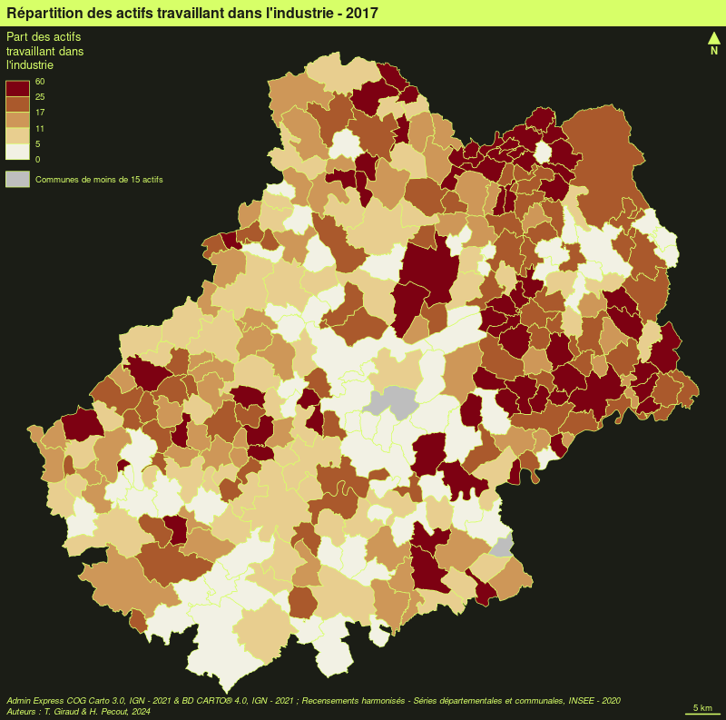

```r
# Nous allons maintenant combiner le nombre total d'actifs et la parts des travailleurs de l'industrie.
mf_export(com, "img/c_ind.png", width = 800)
mf_map(x = com, border = "white", lwd = .2, add = TRUE)
mf_map(x = dep, lwd = 1, col = NA, add = TRUE, lend = 0)
mf_map(com, c("ACT", "SACT_IND"), "prop_choro",
       breaks = bks,
       pal = "Red-Yellow",
       inches = .4,
       border = "white", lwd = .7,
       leg_val_rnd =  c(0,1),
       leg_pos = c(538000,6442000, 538000, 6424000),  # ici les légendes sont positionnées manuellement
       leg_title = c("Nombre d'actifs",
                     "Part des actifs\ndans l'industrie (en %)"),
       col_na = "grey",
       leg_no_data = "Communes de moins de 15 actifs")

# Ajout d'annotations
mf_annotation(x = com[com$NOM_COM=="Biars-sur-Cère",], txt = "Andros",
              col_arrow = "#D7FF68", halo = TRUE, cex = 1)
mf_annotation(x = com[com$NOM_COM=="Figeac",], txt = "Industrie\naéronautique",
              col_arrow = "#D7FF68", pos = "bottomright", halo = TRUE, cex = 1)
mf_annotation(x = com[com$NOM_COM=="Gramat",], txt = "La Quercynoise",
              col_arrow = "#D7FF68", pos = "topleft", halo = TRUE, cex = 1)
mf_title("Répartition des actifs travaillant dans l'industrie - 2017")

# ajout d'un carton ->
mf_inset_on(fig = c(.8,0.98,0.1,0.3))
mf_map(dep, lwd = .1)
mf_map(com, border = NA, add = TRUE, col = "#D7FF68")
box(col = "#D7FF68", lwd = .5)
mf_inset_off()
# <- fin du carton
mf_scale(5)
mf_arrow("topright")
mf_credits(paste0("Admin Express COG Carto 3.0, IGN - 2021 & ",
                  "BD CARTO® 4.0, IGN - 2021 ; Recensements harmonisés - ",
                  "Séries départementales et communales, INSEE - 2020\n",
                  "Auteurs : T. Giraud & H. Pecout, 2024"))
dev.off()
```

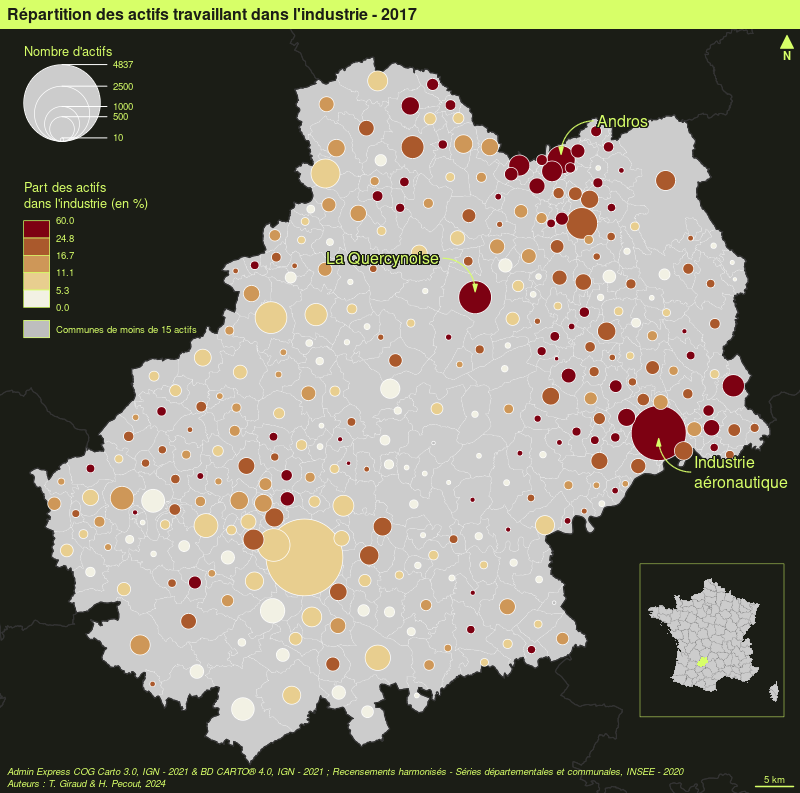